# Analysis example

Hey mate, here’s a little tutorial on how to do the analysis with your data. First up we need to setup the work space. First up we’ll load in the libraries we need. In this case just ggplot2. Then we’ll set the working directory to where our folder is.

```r
# load libraries
library(ggplot2)
# set your working directory
setwd("~/Development/other_people_help/BIOL703/James/analysis")
```

## Reading in the data

First up I saved the data as a `csv` file using Excel. To do this I pasted the primary data to a new sheet and `saved as` a `csv` file. Look at the file called `dataset.csv` I have sent you. Okay first thing we need to do is read it into R. We do this using the function `read.csv()`.

```r
# read in your dataset
raw.data <- read.csv('dataset.csv')
```

Okay, now we need to reorganise the data to make it easier to analyse in R. It pays to think about how you should organise the data during your collection as with some thought before hand you can set yourself up to skip this step. Regardless it’s pretty easy to transform data in R so if it’s easier considerably to record it in one way it’s probably still better to do that. First up let’s look at the data

```r
raw.data
```

```
##     Treatment Week.2 Week.3 Week.4
## 1  Fertiliser     52     47     35
## 2  Fertiliser     18     15     12
## 3  Fertiliser     30     23     28
## 4  Fertiliser     23     21     20
## 5  Fertiliser     26     26     27
## 6  Fertiliser     32     35     19
## 7  Fertiliser     28     26     24
## 8  Fertiliser     45     33     28
## 9  Fertiliser     41     45     35
## 10 Fertiliser     29     26     18
## 11 Fertiliser     22     18     10
## 12 Fertiliser     25     24     22
## 13 Fertiliser     30     30     25
## 14 Fertiliser     32     30     31
```

[output cut: 31 more lines]

Okay so we have the data in a format with 4 columns `[treatment, Week.2, Week.3, Week.4]`. For doing our analysis it will be much easier if we can have `time` as a column so we effectively want to stack the `Week` columns on top of each other. Let’s do that now. Also it can be useful to have an `id` column so we know which plant is which across the analysis.

```r
# make a reorganised data frame
df <- data.frame(id = rep(c(1:45),3),
                 treat = rep(raw.data$Treatment,3),
                 time = c(rep(1,45),rep(2,45),rep(3,45)),
                 leaf_size = c(raw.data$Week.2, raw.data$Week.3, raw.data$Week.4))
```

Okay so we made an id column using `rep(c(1:45),3)` which repeats the numbers `1 -> 45` 3 times. We have then repeated the treatment column 3 times `rep(raw.data$Treatment,3)` and repeated the `time` values `c(rep(1,45),rep(2,45),rep(3,45))`. Finally I have stacked the `leaf_size` data using `c(raw.data$Week.2, raw.data$Week.3, raw.data$Week.4)`.

Here’s what we have now..

```r
df
```

```
##     id      treat time leaf_size
## 1    1 Fertiliser    1        52
## 2    2 Fertiliser    1        18
## 3    3 Fertiliser    1        30
## 4    4 Fertiliser    1        23
## 5    5 Fertiliser    1        26
## 6    6 Fertiliser    1        32
## 7    7 Fertiliser    1        28
## 8    8 Fertiliser    1        45
## 9    9 Fertiliser    1        41
## 10  10 Fertiliser    1        29
## 11  11 Fertiliser    1        22
## 12  12 Fertiliser    1        25
## 13  13 Fertiliser    1        30
## 14  14 Fertiliser    1        32
```

[output cut: 121 more lines]

## Plotting the data

Let’s make a few plots to see what’s going on. First up let’s plot a line plot to see how the groups have changed over time. We will do that using ggplot.

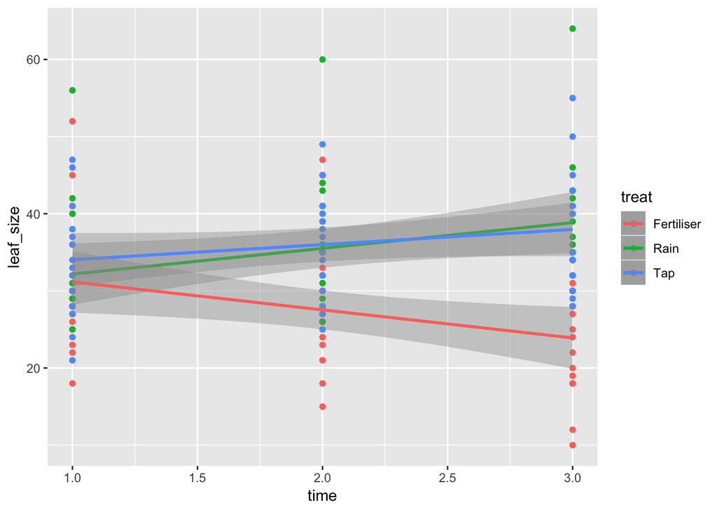

```r
# make a line graph
ggplot(df, aes(x=time, y=leaf_size, colour=treat)) +
  geom_point() +
  stat_smooth(data=subset(df, treat == "Rain"), method = "lm") +
  stat_smooth(data=subset(df, treat == "Tap"), method = "lm") +
  stat_smooth(data=subset(df, treat == "Fertiliser"), method = "lm")
```

Next up let’s make a boxplot of the final measurements.

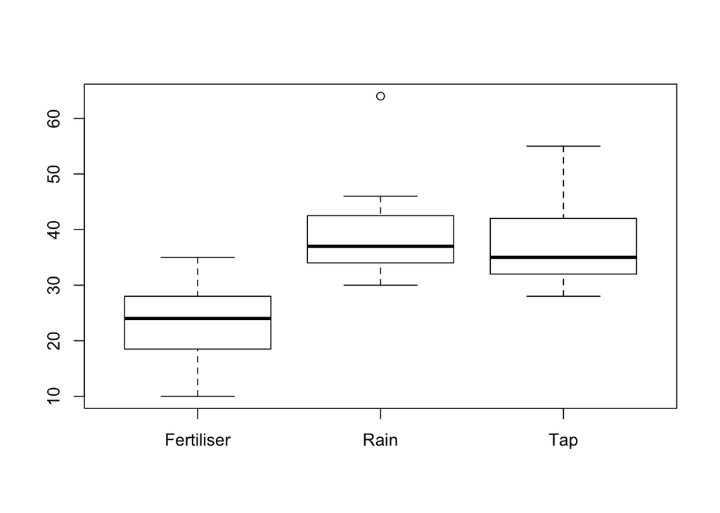

```r
# make a boxplot of final week
boxplot(leaf_size ~ treat, df[df$time == 3,])
```

## Analysis

Now let’s make a linear regression model to test statistically the difference between groups. This is very easy in R.

```r
# linear regression model
fit1 <- lm(formula = leaf_size ~ time*treat, data = df)
# run anova
anova(fit1)
```

```
## Analysis of Variance Table
##
## Response: leaf_size
##             Df Sum Sq Mean Sq F value   Pr(>F)
## time         1   27.8   27.78  0.4290 0.513653
## treat        2 2033.5 1016.76 15.7023 7.88e-07 ***
## time:treat   2  817.6  408.81  6.3135 0.002422 **
## Residuals  129 8353.0   64.75
## ---
## Signif. codes:  0 '***' 0.001 '**' 0.01 '*' 0.05 '.' 0.1 ' ' 1
```

I’ll leave you to interpret these results.

## Post-Hoc analysis

Also it can be useful to look at which of the groups significantly differ from each other (rather than just if certain factors do). We can do this by doing a Tukey analysis.

```r
# post hoc analysis
Tukey <- TukeyHSD(x=aov(fit1))
Tukey
```

```
##   Tukey multiple comparisons of means
##     95% family-wise confidence level
##
## Fit: aov(formula = fit1)
##
## $treat
##                      diff       lwr       upr     p adj
## Rain-Fertiliser 7.9777778  3.955414 12.000142 0.0000193
## Tap-Fertiliser  8.4666667  4.444303 12.489030 0.0000057
## Tap-Rain        0.4888889 -3.533475  4.511253 0.9552671
```

This says Rain and Tap varied very little from each other while Fertiliser differed from both.

## Bonus visulisation

Finally it can be useful to visualise our post-hoc Tukey analysis. We will do this using a script I have previously written which we will load using the `source()` command. This will pull a function I have defined from another R-script.

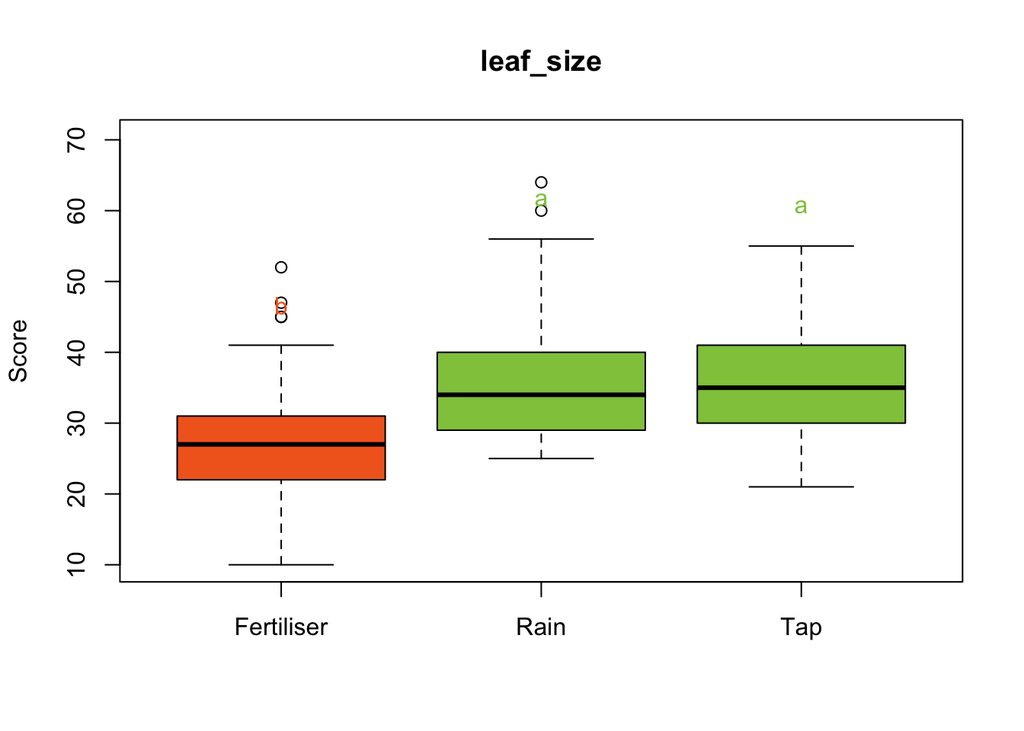

```r
# load the function
source('tukey_plot.R')

# use my fancy function to visulise the Tukey anaylsis
plot.tukeyGroup(Tukey, "leaf_size", "treat")
```

So there ya have it. Also may be worth looking at some of these analyses and visualisations using difference in growth between the first and last measurements but I will leave that to you. Good luck James!